# after_preprocessing

## ch.1 Libraries, Read data

*Load Libraries*

```python
# basic

import pandas as pd
import numpy as np
import warnings
warnings.filterwarnings('ignore')
pd.set_option('display.max_columns', 50, 'display.max_rows', 200)
from itertools import combinations

# plot

import seaborn as sns
import matplotlib.pylab as plt
from matplotlib import font_manager, rc
%matplotlib inline

import platform
your_os = platform.system()
if your_os == 'Linux':
    rc('font', family='NanumGothic')
elif your_os == 'Windows':
    ttf = "c:/Windows/Fonts/malgun.ttf"
    font_name = font_manager.FontProperties(fname=ttf).get_name()
    rc('font', family=font_name)
elif your_os == 'Darwin':
    rc('font', family='AppleGothic')
rc('axes', unicode_minus=False)


# models
import time
from tqdm import tqdm
from sklearn.model_selection import train_test_split
from sklearn.model_selection import cross_val_score
from sklearn.metrics import roc_auc_score
from sklearn.model_selection import StratifiedKFold, KFold

from sklearn.preprocessing import OneHotEncoder
from sklearn.decomposition import PCA
from sklearn.feature_selection import SelectPercentile
from scipy.stats.mstats import gmean
from sklearn.preprocessing import MinMaxScaler
from sklearn.model_selection import ShuffleSplit

from sklearn.ensemble import RandomForestClassifier
from sklearn.neighbors import KNeighborsClassifier
from sklearn.linear_model import LogisticRegression
from sklearn.svm import SVC
from sklearn.ensemble import GradientBoostingClassifier
from lightgbm import LGBMClassifier
from xgboost import XGBClassifier
from sklearn.neural_network import MLPClassifier
from catboost import CatBoostClassifier
from sklearn import svm
from sklearn.ensemble import ExtraTreesClassifier
from catboost import CatBoostClassifier

from sklearn.model_selection import GridSearchCV, RandomizedSearchCV
from bayes_opt import BayesianOptimization
from sklearn.ensemble import VotingClassifier
from vecstack import StackingTransformer
from vecstack import stacking
```

*Read Transaction Data*

```python
df_train = pd.read_csv('X_train.csv', encoding='cp949')
df_test = pd.read_csv('X_test.csv', encoding='cp949')
y_train = pd.read_csv('y_train.csv')
IDtest = df_test.cust_id.unique()
```

Simple data proprecessing

```python
df = pd.concat([df_train, df_test])

## 전체 train_test와 train에 월, 일, 요일, 계절, (월초, 월중, 월말) 칼럼 추가
df['month'] = df['tran_date'].agg(lambda x: pd.to_datetime(x).month)
df['season'] = df['month'].agg(lambda x: 'spring' if x in [3,4,5] else 'summer' if x in [6,7,8] else 'fall' if x in [9,10,11] else 'winter')
df['day'] = df['tran_date'].agg(lambda x: pd.to_datetime(x).day)
df['date'] = df['tran_date'].agg(lambda x: ('월', '화', '수', '목', '금', '토', '일')[pd.to_datetime(x).weekday()])
df['month_when'] = df['day'].agg(lambda x: '0to10' if x in list(range(1,11)) else '11to20' if x in list(range(11,21)) else '21to31')

tr = df.query('cust_id not in @IDtest')
tr2 = df.query('cust_id in @IDtest')
tr = pd.merge(tr, y_train, on='cust_id')
trs = [tr, tr2]

for i in trs:

    i['amount_range'] = pd.cut(i['amount'],
       bins=[-300000000,0, 99999, 199999, 299990, 399990, 499990, 699990,999990, 1999990, 4999990, 800000000 ],
      right = False,
      labels = ['환불금액', '10만원이하', '10만원이상 20만원미만', '20만원이상 30만원미만', '30만원이상 40만원미만', '40만원이상 50만원미만', '50만원이상 70만원미만', '70만원이상 100만원미만', '100만원이상 200만원미만', '200만원이상 500만원미만', '500만원이상'])
```

*파생변수를 저장할 빈 리스트를 만든다.*

```python
features = [] # 개인과제에서 생성된 feature들 담음
features1 = [] # 마지막에 train 끼리 모아 저장
features2 = [] # 마지막에 test 끼리 모아 저장
```

## ch.2 Features

## 1차 생성 features

### 1. 가격적 관점

만든 피쳐들

년 총 구매금액에 따른 등급 (실제 롯데백화점 등급 기준 적용)

- 롯데백화점 MVG 조건(2020년 기준)

```python
# 나누는 함수 정의
def divide_class(x):
    if 4000000<= x < 8000000:
        return 200
    elif 8000000<= x < 18000000:
        return 300
    elif 18000000<= x <40000000:
        return 400
    elif 40000000<= x <60000000:
        return 500
    elif 60000000<= x <100000000:
        return 600
    elif x>= 100000000:
        return 700
    else:
        return 100

for i in trs:

    temp_amountdf = i.groupby('cust_id')['amount'].sum().reset_index()

    temp_amountdf['class'] = temp_amountdf['amount'].agg(divide_class)

    f = temp_amountdf[['cust_id', 'class']]

    features.append(f); f
```

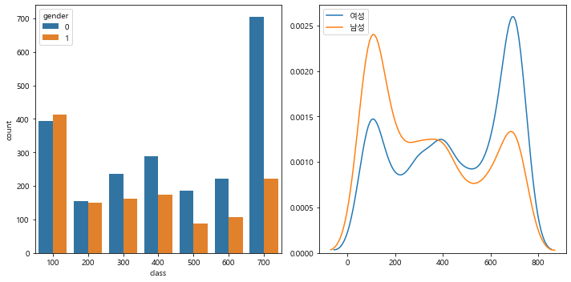

```python
# vip고객을 구분하는 피쳐 생성
temp_amountdf = tr.groupby('cust_id')['amount'].sum().reset_index()

temp_amountdf['class'] = temp_amountdf['amount'].agg(divide_class)

f = temp_amountdf[['cust_id', 'class']]

f['gender'] = y_train['gender']

figure, ax = plt.subplots(1, 2, figsize=(10, 5))
sns.countplot(data=f, x='class', hue='gender', ax=ax[0])
sns.kdeplot(f.query('gender==0')['class'], ax=ax[1], label='여성')
sns.kdeplot(f.query('gender==1')['class'], ax=ax[1], label='남성')
plt.tight_layout()
plt.show()
```

총구매액

```python
for i in trs:
    f = i.groupby('cust_id')['amount'].agg([('total_amount',np.sum), ]).reset_index()

    bins2 =  [i*10000000 for i in range(235)]
    f['total_amount_range2'] = pd.cut(f.total_amount,bins= bins2,labels=[i for i in range(0,len(bins2)-1)])

    f = f.fillna(0)
    f = f.drop('total_amount', axis=1)
    features.append(f); f
```

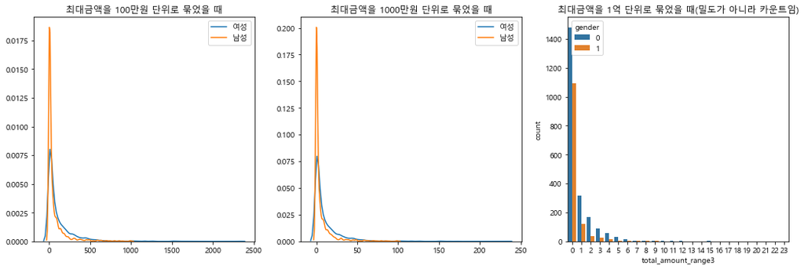

```python
f = tr.groupby('cust_id')['amount'].agg([('total_amount',np.sum)]).reset_index()

f['gender'] = y_train['gender']

bins = [i*1000000 for i in range(2325)]
bins2 =  [i*10000000 for i in range(235)]
bins3 =  [i*100000000 for i in range(25)]

f['total_amount_range1'] = pd.cut(f.total_amount,bins= bins,labels=[i for i in range(0,len(bins)-1)])
f['total_amount_range2'] = pd.cut(f.total_amount,bins= bins2,labels=[i for i in range(0,len(bins2)-1)])
f['total_amount_range3'] = pd.cut(f.total_amount,bins= bins3,labels=[i for i in range(0,len(bins3)-1)])

f = f.fillna(0)

figure, ax = plt.subplots(1, 3, figsize=(15, 5))
sns.kdeplot(f.query('gender==0')['total_amount_range1'], ax=ax[0], label='여성')
sns.kdeplot(f.query('gender==1')['total_amount_range1'], ax=ax[0], label='남성')
ax[0].set_title('최대금액을 100만원 단위로 묶었을 때')
sns.kdeplot(f.query('gender==0')['total_amount_range2'], ax=ax[1], label='여성')
sns.kdeplot(f.query('gender==1')['total_amount_range2'], ax=ax[1], label='남성')
ax[1].set_title('최대금액을 1000만원 단위로 묶었을 때')
sns.countplot(data=f, x='total_amount_range3', hue='gender', ax=ax[2])
ax[2].set_title('최대금액을 1억 단위로 묶었을 때(밀도가 아니라 카운트임)')

plt.tight_layout()
plt.show()
```

구매건수

```python
for i in trs:
    f = i.groupby('cust_id')['amount'].agg([('num_of_purchase', np.size), ]).reset_index()

    bins=[0, 10, 20, 30, 40, 50, 60, 70, 80, 90, 100, 110, 120, 130, 140, 150, 160, 170, 180, 190, 200, 300, 450, 600, 750, 900, 1050, 1200, 1350, 1500]
    f['purchase_count'] = pd.cut(f.num_of_purchase,bins= bins,labels=[i*10 for i in range(1,len(bins))])

    f = f.drop('num_of_purchase', axis=1)
    f = f.fillna(10)
    features.append(f); f
```

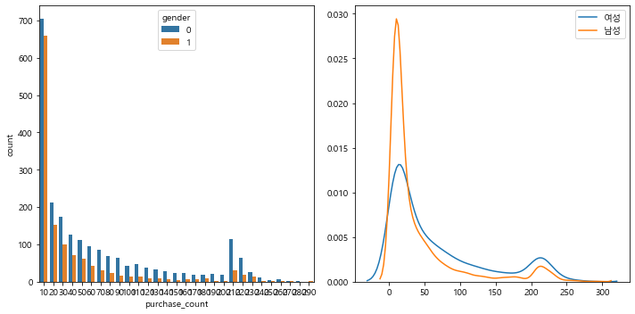

```python
f = tr.groupby('cust_id')['amount'].agg([('num_of_purchase', np.size)]).reset_index()

f['gender'] = y_train['gender']

bins=[0, 10, 20, 30, 40, 50, 60, 70, 80, 90, 100, 110, 120, 130, 140, 150, 160, 170, 180, 190, 200, 300, 450, 600, 750, 900, 1050, 1200, 1350, 1500]

f['purchase_count'] = pd.cut(f.num_of_purchase,bins= bins,labels=[i*10 for i in range(1,len(bins))])

figure, ax = plt.subplots(1, 2, figsize=(10, 5))
sns.countplot(data=f, x='purchase_count', hue='gender', ax=ax[0])
sns.kdeplot(f.query('gender==0')['purchase_count'], ax=ax[1], label='여성')
sns.kdeplot(f.query('gender==1')['purchase_count'], ax=ax[1], label='남성')
plt.tight_layout()
plt.show()
```

평균구매액

```python
for i in trs:
    f = i.groupby('cust_id')['amount'].agg([
        ('total_amount_avg', lambda x: np.round(np.mean(x))),]).reset_index()

    f.total_amount_avg = f.total_amount_avg.apply(lambda x: 0 if x<0 else x)

    bins = [i*100000 for i in range(1545)]
    f['total_amount_avg_range1'] = pd.cut(f.total_amount_avg,bins= bins,labels=[i for i in range(0,len(bins)-1)])


    f = f.drop('total_amount_avg', axis=1)
    f = f.fillna(0)
    features.append(f); f
```

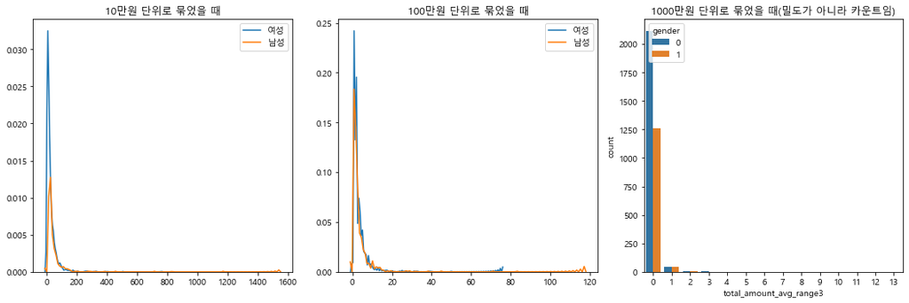

```python
f = tr.groupby('cust_id')['amount'].agg([('total_amount_avg', lambda x: np.round(np.mean(x))),]).reset_index()

f.total_amount_avg = f.total_amount_avg.apply(lambda x: 0 if x<0 else x)

f['gender'] = y_train['gender']

bins = [i*100000 for i in range(1545)]
bins2 =  [i*1000000 for i in range(155)]
bins3 =  [i*10000000 for i in range(15)]

f['total_amount_avg_range1'] = pd.cut(f.total_amount_avg,bins= bins,labels=[i for i in range(0,len(bins)-1)])
f['total_amount_avg_range2'] = pd.cut(f.total_amount_avg,bins= bins2,labels=[i for i in range(0,len(bins2)-1)])
f['total_amount_avg_range3'] = pd.cut(f.total_amount_avg, bins= bins3,labels=[i for i in range(0,len(bins3)-1)])


figure, ax = plt.subplots(1, 3, figsize=(15, 5))
sns.kdeplot(f.query('gender==0')['total_amount_avg_range1'], ax=ax[0], label='여성')
sns.kdeplot(f.query('gender==1')['total_amount_avg_range1'], ax=ax[0], label='남성')
ax[0].set_title('10만원 단위로 묶었을 때')
sns.kdeplot(f.query('gender==0')['total_amount_avg_range2'], ax=ax[1], label='여성')
sns.kdeplot(f.query('gender==1')['total_amount_avg_range2'], ax=ax[1], label='남성')
ax[1].set_title('100만원 단위로 묶었을 때')
sns.countplot(data=f, x='total_amount_avg_range3', hue='gender', ax=ax[2])
ax[2].set_title('1000만원 단위로 묶었을 때(밀도가 아니라 카운트임)')

plt.tight_layout()
plt.show()
```

최대구매액

```python
for i in trs:
    f = i.groupby('cust_id')['amount'].agg([('max_amount', np.max),]).reset_index()


    bins2  = [i*10000000 for i in range(71)]
    f['max_amount_range2'] = pd.cut(f.max_amount, bins= bins2,labels=[i for i in range(1,len(bins2))])


    f = f.drop('max_amount', axis=1)
    f.max_amount_range2 = f['max_amount_range2'].fillna(1)
    features.append(f); f
```

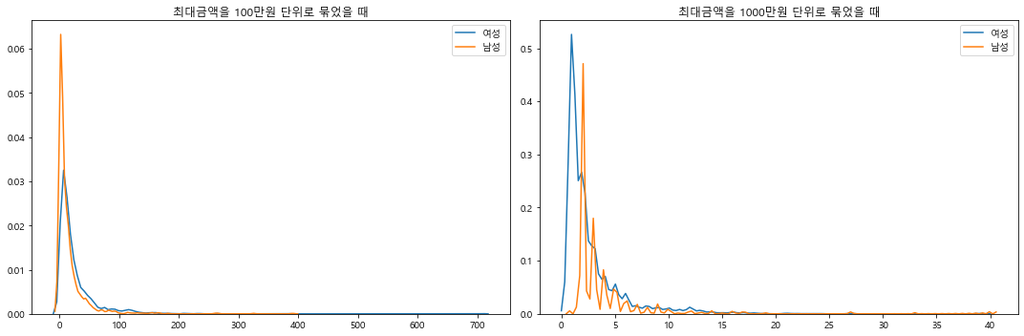

```python
f = tr.groupby('cust_id')['amount'].agg([ ('max_amount', np.max),]).reset_index()

f['gender'] = y_train['gender']


bins = [i*1000000 for i in range(710)]
bins2  = [i*10000000 for i in range(71)]

f['max_amount_range1'] = pd.cut(f.max_amount, bins= bins,labels=[i for i in range(1,len(bins))])
f['max_amount_range2'] = pd.cut(f.max_amount, bins= bins2,labels=[i for i in range(1,len(bins2))])


figure, ax = plt.subplots(1, 2, figsize=(15, 5))
sns.kdeplot(f.query('gender==0')['max_amount_range1'], ax=ax[0], label='여성')
sns.kdeplot(f.query('gender==1')['max_amount_range1'], ax=ax[0], label='남성')
ax[0].set_title('최대금액을 100만원 단위로 묶었을 때')
sns.kdeplot(f.query('gender==0')['max_amount_range2'], ax=ax[1], label='여성')
sns.kdeplot(f.query('gender==1')['max_amount_range2'], ax=ax[1], label='남성')
ax[1].set_title('최대금액을 1000만원 단위로 묶었을 때')
plt.tight_layout()
plt.show()
```

내점당 구매건수

```python
# 내점 당 구매액 = 총구매액 / 내점일수
for i in trs:

    visits = i.groupby('cust_id')['tran_date'].agg(lambda x: x.nunique()) # 내점일수

    f = (i.groupby('cust_id')['amount'].size() / visits).reset_index().rename(columns={0 : "per_visit_pur_num"})

    f.per_visit_pur_num = f.per_visit_pur_num.apply(lambda x: round(x))

    features.append(f); f
```

```python
visits = tr.groupby('cust_id')['tran_date'].agg(lambda x: x.nunique()) # 내점일수

f = (tr.groupby('cust_id')['amount'].size() / visits).reset_index().rename(columns={0 : "per_visit_pur_num"})

f.per_visit_pur_num = f.per_visit_pur_num.apply(lambda x: round(x))

f['gender'] = y_train['gender']

bins = [i for i in range(22)]
bins2 =  [i*2 for i in range(11)]

f['per_visit_pur_num1'] = pd.cut(f.per_visit_pur_num,bins= bins,labels=[i for i in range(0,len(bins)-1)])
f['per_visit_pur_num2'] = pd.cut(f.per_visit_pur_num,bins= bins2,labels=[i for i in range(0,len(bins2)-1)])
```

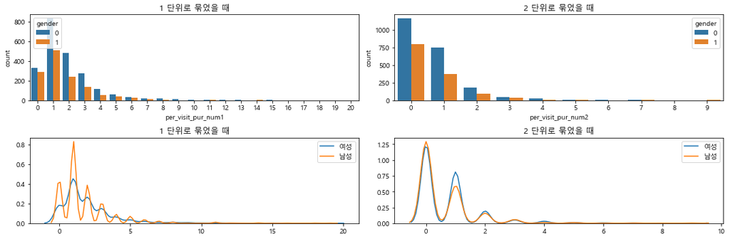

```python
figure, ax = plt.subplots(2, 2, figsize=(15, 5))
sns.countplot(data=f, x='per_visit_pur_num1', hue='gender', ax=ax[0,0])
ax[0,0].set_title('1 단위로 묶었을 때')
sns.countplot(data=f, x='per_visit_pur_num2', hue='gender', ax=ax[0,1])
ax[0,1].set_title('2 단위로 묶었을 때')

sns.kdeplot(f.query('gender==0')['per_visit_pur_num1'], ax=ax[1,0], label='여성')
sns.kdeplot(f.query('gender==1')['per_visit_pur_num1'], ax=ax[1,0], label='남성')
ax[1,0].set_title('1 단위로 묶었을 때')
sns.kdeplot(f.query('gender==0')['per_visit_pur_num2'], ax=ax[1,1], label='여성')
sns.kdeplot(f.query('gender==1')['per_visit_pur_num2'], ax=ax[1,1], label='남성')
ax[1,1].set_title('2 단위로 묶었을 때')

plt.tight_layout()
plt.show()
```

## ────────────────────────────────────────────────────────

### 2. 시간적 관점

만든 피쳐들

내점일수

```python
for i in trs:
    f = i.groupby('cust_id')['tran_date'].agg([
        ('total_visit',lambda x: x.str[:10].nunique())]).reset_index()

    bins2 =  [i*2 for i in range(143)]
    f['total_visit2'] = pd.cut(f.total_visit,bins= bins2,labels=[i for i in range(0,len(bins2)-1)])

    f = f.drop('total_visit', axis=1)
    f = f.fillna(0)
    features.append(f); f
```

```python
f = tr.groupby('cust_id')['tran_date'].agg([('total_visit',lambda x: x.str[:10].nunique()),]).reset_index()

f['gender'] = y_train['gender']

bins = [i for i in range(285)]
bins2 =  [i*2 for i in range(143)]

f['total_visit1'] = pd.cut(f.total_visit,bins= bins,labels=[i for i in range(0,len(bins)-1)])
f['total_visit2'] = pd.cut(f.total_visit,bins= bins2,labels=[i for i in range(0,len(bins2)-1)])
```

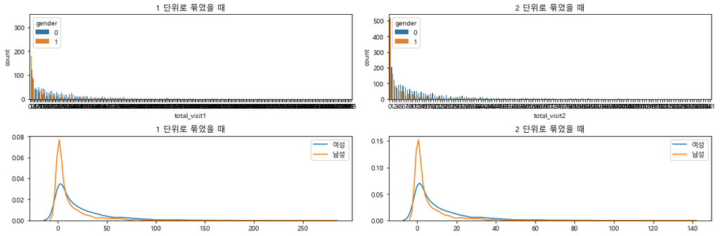

```python
figure, ax = plt.subplots(2, 2, figsize=(15, 5))
sns.countplot(data=f, x='total_visit1', hue='gender', ax=ax[0,0])
ax[0,0].set_title('1 단위로 묶었을 때')
sns.countplot(data=f, x='total_visit2', hue='gender', ax=ax[0,1])
ax[0,1].set_title('2 단위로 묶었을 때')

sns.kdeplot(f.query('gender==0')['total_visit1'], ax=ax[1,0], label='여성')
sns.kdeplot(f.query('gender==1')['total_visit1'], ax=ax[1,0], label='남성')
ax[1,0].set_title('1 단위로 묶었을 때')
sns.kdeplot(f.query('gender==0')['total_visit2'], ax=ax[1,1], label='여성')
sns.kdeplot(f.query('gender==1')['total_visit2'], ax=ax[1,1], label='남성')
ax[1,1].set_title('2 단위로 묶었을 때')

plt.tight_layout()
plt.show()
```

구매주기

```python
for i in trs:
    f = i.groupby('cust_id')['tran_date'].agg([('buying_cycle', lambda x: int((x.astype('datetime64').max() - x.astype('datetime64').min()).days / x.str[:10].nunique()))]).reset_index()

    bins2 =  [i*2 for i in range(78)]
    f['buying_cycle2'] = pd.cut(f.buying_cycle,bins= bins2,labels=[i for i in range(0,len(bins2)-1)])

    f = f.drop('buying_cycle', axis=1)
    f.buying_cycle2 = f['buying_cycle2'].fillna(0)
    features.append(f); f
```

```python
f = tr.groupby('cust_id')['tran_date'].agg([('buying_cycle', lambda x: int((x.astype('datetime64').max() - x.astype('datetime64').min()).days / x.str[:10].nunique()))]).reset_index()

f['gender'] = y_train['gender']

bins = [i for i in range(166)]
bins2 =  [i*2 for i in range(78)]

f['buying_cycle1'] = pd.cut(f.buying_cycle,bins= bins,labels=[i for i in range(0,len(bins)-1)])
f['buying_cycle2'] = pd.cut(f.buying_cycle,bins= bins2,labels=[i for i in range(0,len(bins2)-1)])
```

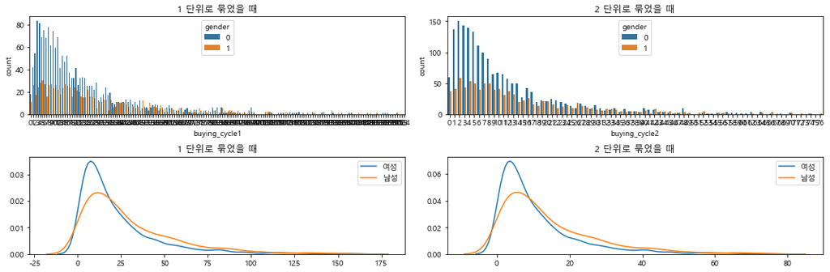

```python
figure, ax = plt.subplots(2, 2, figsize=(15, 5))
sns.countplot(data=f, x='buying_cycle1', hue='gender', ax=ax[0,0])
ax[0,0].set_title('1 단위로 묶었을 때')
sns.countplot(data=f, x='buying_cycle2', hue='gender', ax=ax[0,1])
ax[0,1].set_title('2 단위로 묶었을 때')

sns.kdeplot(f.query('gender==0')['buying_cycle1'], ax=ax[1,0], label='여성')
sns.kdeplot(f.query('gender==1')['buying_cycle1'], ax=ax[1,0], label='남성')
ax[1,0].set_title('1 단위로 묶었을 때')
sns.kdeplot(f.query('gender==0')['buying_cycle2'], ax=ax[1,1], label='여성')
sns.kdeplot(f.query('gender==1')['buying_cycle2'], ax=ax[1,1], label='남성')
ax[1,1].set_title('2 단위로 묶었을 때')

plt.tight_layout()
plt.show()
```

선호방문계절

```python
## 고객별 선호방문계절
for i in trs:
    f = i.groupby('cust_id')['season'].agg([
        ('perfer_season', lambda x: x.value_counts().index[0])
    ]).reset_index()

## spring은 0, summer는 1, fall은 2, winter는 3으로 바꿔주기
    f.perfer_season = f.perfer_season.map({'spring': 0, 'summer':1, 'fall':2, 'winter':3})

    features.append(f); f
```

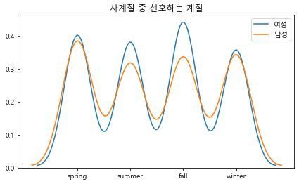

```python
## 고객별 선호방문계절
f = tr.groupby('cust_id')['season'].agg([('prefer_season', lambda x: x.value_counts().index[0])]).reset_index()

## spring은 0, summer는 1, fall은 2, winter는 3으로 바꿔주기
f.prefer_season = f.prefer_season.map({'spring': 0, 'summer':1, 'fall':2, 'winter':3})

f['gender'] = y_train['gender']

plt.figure(figsize=(7,4))
sns.kdeplot(f.query('gender==0').prefer_season, label = '여성')
sns.kdeplot(f.query('gender==1').prefer_season, label = '남성')
plt.xticks([0,1,2,3],['spring','summer','fall','winter'])
plt.title('사계절 중 선호하는 계절')
plt.show()
```

계절별 구매비율(s:3to5, s:6to8, f:9to11, w:12to2)

```python
for i in trs:

    f = i.groupby('cust_id')['tran_date'].agg([
        ('spring_pur_ratio', lambda x: np.mean( pd.to_datetime(x).dt.month.isin([3,4,5]))),
        ('summer_pur_ratio', lambda x: np.mean( pd.to_datetime(x).dt.month.isin([6,7,8]))),
        ('fall_pur_ratio', lambda x: np.mean( pd.to_datetime(x).dt.month.isin([9,10,11]))),
        ('winter_pur_ratio', lambda x: np.mean( pd.to_datetime(x).dt.month.isin([1,2,12])))
    ]).reset_index()

    features.append(f); f
```

```python
f = tr.groupby('cust_id')['tran_date'].agg([
    ('spring_pur_ratio', lambda x: np.mean( pd.to_datetime(x).dt.month.isin([3,4,5]))),
    ('summer_pur_ratio', lambda x: np.mean( pd.to_datetime(x).dt.month.isin([6,7,8]))),
    ('fall_pur_ratio', lambda x: np.mean( pd.to_datetime(x).dt.month.isin([9,10,11]))),
    ('winter_pur_ratio', lambda x: np.mean( pd.to_datetime(x).dt.month.isin([1,2,12])))
]).reset_index()

f['gender'] = y_train['gender']
```

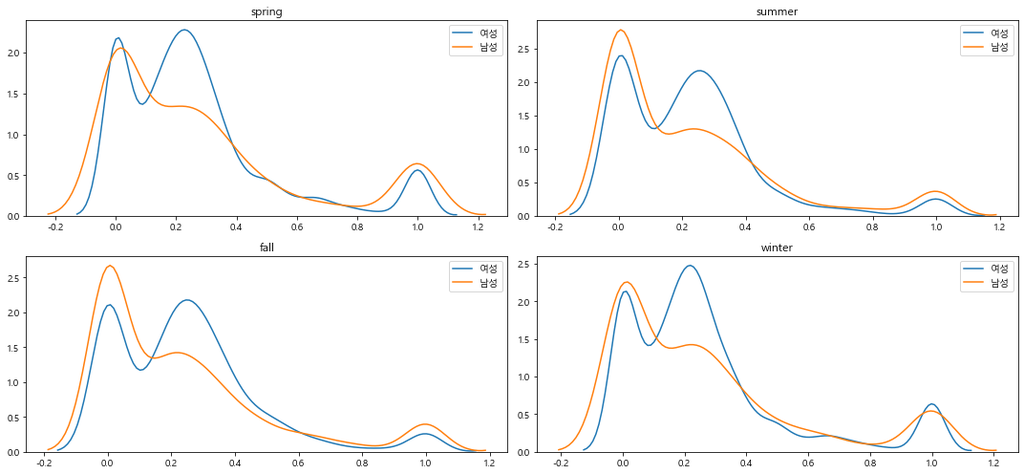

```python
figure, ax = plt.subplots(2, 2, figsize=(15, 7))
sns.kdeplot(f.query('gender==0').spring_pur_ratio, label = '여성', ax=ax[0,0])
sns.kdeplot(f.query('gender==1').spring_pur_ratio, label = '남성', ax=ax[0,0])
ax[0,0].set_title('spring')
ax[0,1].set_title('summer')
sns.kdeplot(f.query('gender==0').summer_pur_ratio, label = '여성', ax=ax[0,1])
sns.kdeplot(f.query('gender==1').summer_pur_ratio, label = '남성', ax=ax[0,1])
ax[1,0].set_title('fall')
sns.kdeplot(f.query('gender==0').fall_pur_ratio, label = '여성', ax=ax[1,0])
sns.kdeplot(f.query('gender==1').fall_pur_ratio, label = '남성', ax=ax[1,0])
ax[1,1].set_title('winter')
sns.kdeplot(f.query('gender==0').winter_pur_ratio, label = '여성', ax=ax[1,1])
sns.kdeplot(f.query('gender==1').winter_pur_ratio, label = '남성', ax=ax[1,1])

plt.tight_layout()
plt.show()
```

선호방문월

```python
## 선호방문월

for i in trs:

    f = i.groupby('cust_id')['month'].agg([
        ('prefer_month', lambda x: x.value_counts(1).index[0])
    ]).reset_index()

    features.append(f); f
```

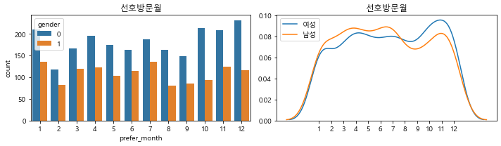

```python
f = tr.groupby('cust_id')['month'].agg([('prefer_month', lambda x: x.value_counts(1).index[0])]).reset_index()

f['gender'] = y_train['gender']

figure, ax = plt.subplots(1, 2, figsize=(10, 3))
sns.countplot(data=f, x='prefer_month', hue='gender', ax=ax[0])
ax[0].set_title('선호방문월')

sns.kdeplot(f.query('gender==0').prefer_month, label = '여성', ax=ax[1])
sns.kdeplot(f.query('gender==1').prefer_month, label = '남성', ax=ax[1])
plt.xticks([i for i in range(1,13)])
plt.title('선호방문월')

plt.tight_layout()
plt.show()
```

구매비율

```
- 12달 중 1월, 2월 그리고 9월을 피쳐로 채택
```

```python
## 월별 구매비율
for i in trs:

    # 고객별 구매금액 총합
    total_amount =  i.groupby('cust_id')['amount'].sum()

    # 고객별 월별 구매금액
    temp_monthpivot = pd.pivot_table(i, index='cust_id', columns='month', values='amount', aggfunc=sum, fill_value=0)

    # 칼럼명 변경화
    oldname = temp_monthpivot.columns.tolist()
    newname = [str(i)+'_month_amount' for i in oldname]
    temp_monthpivot = temp_monthpivot.rename(columns=dict(zip(oldname, newname)))

    # 고객별 월별 구매금액비율
    for i in range(len(temp_monthpivot.columns)):

        temp_monthpivot.iloc[:,i] = temp_monthpivot.iloc[:,i] / total_amount

    f = temp_monthpivot.reset_index()
    f = f.replace([float('inf'), -float('inf')], [1, -1]).fillna(0)
    f = f[['cust_id', '1_month_amount', '2_month_amount','9_month_amount']]
    features.append(f); f
```

```python
# 고객별 구매금액 총합
total_amount =  tr.groupby('cust_id')['amount'].sum()

# 고객별 월별 구매금액
temp_monthpivot = pd.pivot_table(tr, index='cust_id', columns='month', values='amount', aggfunc=sum, fill_value=0)

# 고객별 월별 구매금액비율
for i in range(len(temp_monthpivot.columns)):

    temp_monthpivot.iloc[:,i] = temp_monthpivot.iloc[:,i] / total_amount

f = temp_monthpivot.reset_index()
f = f.replace([float('inf'), -float('inf')], [1, -1]).fillna(0)

f['gender'] = y_train['gender']
```

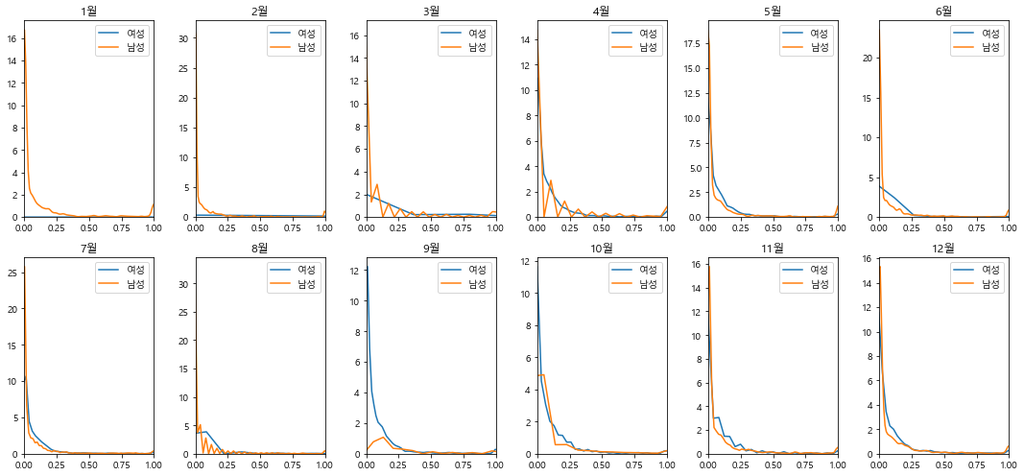

```python
figure, ax = plt.subplots(2, 6, figsize=(15, 7))

for month in range(1,7):
    sns.kdeplot(f.query('gender==0')[month], label = '여성', ax=ax[0,month-1])
    sns.kdeplot(f.query('gender==1')[month], label = '남성', ax=ax[0,month-1])
    ax[0,month-1].set_xlim(0,1)
    ax[0,month-1].set_title(f'{month}월')

temp = 0
for month in range(7,13):

    sns.kdeplot(f.query('gender==0')[month], label = '여성', ax=ax[1,temp])
    sns.kdeplot(f.query('gender==1')[month], label = '남성', ax=ax[1,temp])
    ax[1,temp].set_xlim(0,1)
    ax[1,temp].set_title(f'{month}월')
    temp += 1

plt.tight_layout()
plt.show()
```

월초, 월중, 월말 방문비율

```python
## 고객별 월초, 월중, 월말 방문비율

for i in trs:

    # 총 방문일수
    total_visits = i.groupby('cust_id')['tran_date'].nunique()

    # 고객별 월초, 월중, 월말 방문일수
    temp_monthwhenpivot = pd.pivot_table(i, index='cust_id', columns='month_when', values='tran_date', aggfunc=(lambda x: x.nunique()), fill_value=0)

    # 칼럼명 변경화
    oldname = temp_monthwhenpivot.columns.tolist()
    newname = [str(i)+'_visits' for i in oldname]
    temp_monthwhenpivot = temp_monthwhenpivot.rename(columns=dict(zip(oldname, newname)))

    # 고객별 월초, 월중, 월말 방문비율

    for i in range(len(temp_monthwhenpivot.columns)):

            temp_monthwhenpivot.iloc[:,i] = temp_monthwhenpivot.iloc[:,i] / total_visits

    f = temp_monthwhenpivot.reset_index()

    features.append(f); f
```

```python
# 총 방문일수
total_visits = tr.groupby('cust_id')['tran_date'].nunique()

# 고객별 월초, 월중, 월말 방문일수
temp_monthwhenpivot = pd.pivot_table(tr, index='cust_id', columns='month_when', values='tran_date', aggfunc=(lambda x: x.nunique()), fill_value=0)

# 고객별 월초, 월중, 월말 방문비율

for i in range(len(temp_monthwhenpivot.columns)):

        temp_monthwhenpivot.iloc[:,i] = temp_monthwhenpivot.iloc[:,i] / total_visits

f = temp_monthwhenpivot.reset_index()

f['gender'] = y_train['gender']
```

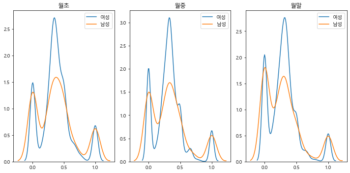

```python
figure, ax = plt.subplots(1, 3, figsize=(10, 5))
sns.kdeplot(f.query('gender==0')['0to10'], label = '여성', ax=ax[0])
sns.kdeplot(f.query('gender==1')['0to10'], label = '남성', ax=ax[0])
ax[0].set_title('월초')
sns.kdeplot(f.query('gender==0')['11to20'], label = '여성', ax=ax[1])
sns.kdeplot(f.query('gender==1')['11to20'], label = '남성', ax=ax[1])
ax[1].set_title('월중')
sns.kdeplot(f.query('gender==0')['21to31'], label = '여성', ax=ax[2])
sns.kdeplot(f.query('gender==1')['21to31'], label = '남성', ax=ax[2])
ax[2].set_title('월말')

plt.tight_layout()
plt.show()
```

월초, 월중, 월말 구매비율

```python
##고객별 월초, 월중, 월말 구매비율

for i in trs:

    # 고객별 구매금액 총합
    total_amount =  i.groupby('cust_id')['amount'].sum()

    # 고객별 월초, 월중, 월말별 구매금액
    temp_monthwhenpivot = pd.pivot_table(i, index='cust_id', columns='month_when', values='amount', aggfunc=sum, fill_value=0)

    # 칼럼명 변경화
    oldname = temp_monthwhenpivot.columns.tolist()
    newname = [str(i)+'_amount' for i in oldname]
    temp_monthwhenpivot = temp_monthwhenpivot.rename(columns=dict(zip(oldname, newname)))

    # 고객별 월초, 월중, 월말별 구매금액비율
    for i in range(len(temp_monthwhenpivot.columns)):

        temp_monthwhenpivot.iloc[:,i] = temp_monthwhenpivot.iloc[:,i] / total_amount

    f = temp_monthwhenpivot.reset_index()
    f = f.replace([float('inf'), -float('inf')], [1, -1]).fillna(0)

    features.append(f); f
```

```python
# 고객별 구매금액 총합
total_amount = tr.groupby('cust_id')['amount'].sum()

# 고객별 월초, 월중, 월말별 구매금액
temp_monthwhenpivot = pd.pivot_table(tr, index='cust_id', columns='month_when', values='amount', aggfunc=sum, fill_value=0)

# 고객별 월초, 월중, 월말별 구매금액비율
for i in range(len(temp_monthwhenpivot.columns)):

    temp_monthwhenpivot.iloc[:,i] = temp_monthwhenpivot.iloc[:,i] / total_amount

f = temp_monthwhenpivot.reset_index()
f = f.replace([float('inf'), -float('inf')], [1, -1]).fillna(0)

f['gender'] = y_train['gender']
```

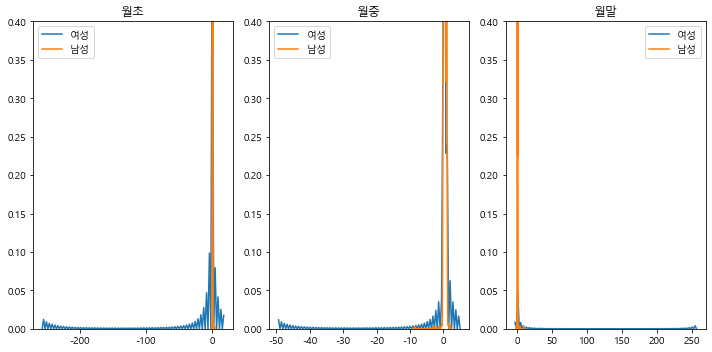

```python
figure, ax = plt.subplots(1, 3, figsize=(10, 5))
sns.kdeplot(f.query('gender==0')['0to10'], label = '여성', ax=ax[0])
sns.kdeplot(f.query('gender==1')['0to10'], label = '남성', ax=ax[0])
ax[0].set_title('월초')
ax[0].set_ylim(0,0.4)
sns.kdeplot(f.query('gender==0')['11to20'], label = '여성', ax=ax[1])
sns.kdeplot(f.query('gender==1')['11to20'], label = '남성', ax=ax[1])
ax[1].set_title('월중')
ax[1].set_ylim(0,0.4)
sns.kdeplot(f.query('gender==0')['21to31'], label = '여성', ax=ax[2])
sns.kdeplot(f.query('gender==1')['21to31'], label = '남성', ax=ax[2])
ax[2].set_title('월말')
ax[2].set_ylim(0,0.4)
plt.tight_layout()
plt.show()
```

월초, 월중, 월말 구매건수

```python
## 고객별 월초, 월중, 월말 구매건수

for i in trs:

    temp_monthwhenpivot = pd.pivot_table(i, index='cust_id', columns='month_when', values='amount', aggfunc=np.size, fill_value=0)



    # 칼럼명 변경화
    oldname = temp_monthwhenpivot.columns.tolist()
    newname = [str(i)+'_buy' for i in oldname]
    temp_monthwhenpivot = temp_monthwhenpivot.rename(columns=dict(zip(oldname, newname)))

    f = temp_monthwhenpivot.reset_index()

    bins = [i*10 for i in range(57)]
    bins2 = [i*10 for i in range(65)]
    bins3 = [i*10 for i in range(67)]
    labels = [i for i in range(len(bins)-1)]
    labels2 = [i for i in range(len(bins2)-1)]
    labels3 = [i for i in range(len(bins3)-1)]
    f['0to10_10unit'] = pd.cut(f['0to10_buy'], bins=bins, labels = labels)
    f['11to20_20unit'] = pd.cut(f['11to20_buy'], bins=bins2, labels = labels2)
    f['21to31_30unit'] = pd.cut(f['21to31_buy'], bins=bins3, labels = labels3)
    f = f.drop('0to10_buy', axis=1)
    f = f.drop('11to20_buy', axis=1)
    f = f.drop('21to31_buy', axis=1)
    f = f.fillna(0)

    features.append(f); f
```

```python
temp_monthwhenpivot = pd.pivot_table(tr, index='cust_id', columns='month_when', values='amount', aggfunc=np.size, fill_value=0)

f = temp_monthwhenpivot.reset_index()

f['gender'] = y_train['gender']
```

```python
bins = [i*10 for i in range(57)]
bins2 = [i*10 for i in range(65)]
bins3 = [i*10 for i in range(67)]
labels = [i for i in range(len(bins)-1)]
labels2 = [i for i in range(len(bins2)-1)]
labels3 = [i for i in range(len(bins3)-1)]
f['0to10_10unit'] = pd.cut(f['0to10'], bins=bins, labels = labels)
f['11to20_20unit'] = pd.cut(f['11to20'], bins=bins2, labels = labels2)
f['21to31_30unit'] = pd.cut(f['21to31'], bins=bins3, labels = labels3)

f = f.fillna(0)
```

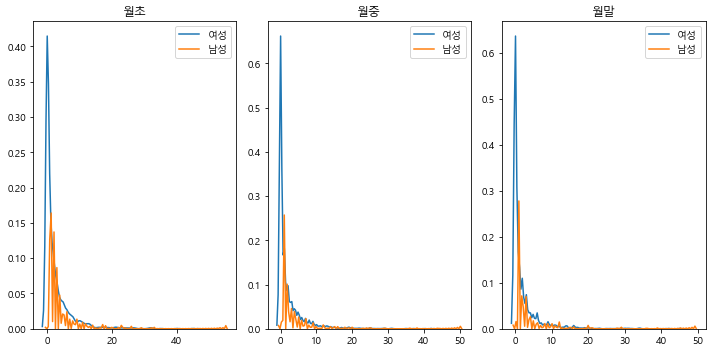

```python
figure, ax = plt.subplots(1, 3, figsize=(10, 5))
sns.kdeplot(f.query('gender==0')['0to10_10unit'], label = '여성', ax=ax[0])
sns.kdeplot(f.query('gender==1')['0to10_10unit'], label = '남성', ax=ax[0])
ax[0].set_title('월초')
sns.kdeplot(f.query('gender==0')['11to20_20unit'], label = '여성', ax=ax[1])
sns.kdeplot(f.query('gender==1')['11to20_20unit'], label = '남성', ax=ax[1])
ax[1].set_title('월중')
sns.kdeplot(f.query('gender==0')['21to31_30unit'], label = '여성', ax=ax[2])
sns.kdeplot(f.query('gender==1')['21to31_30unit'], label = '남성', ax=ax[2])
ax[2].set_title('월말')

plt.tight_layout()
plt.show()
```

선호방문요일

```python
## 선호방문요일

for i in trs:

    f = i.groupby('cust_id')['date'].agg([
        ('prefer_date', lambda x: x.value_counts().index[0])
    ]).reset_index()

    # 요일을 숫자로 바꿔주기: 월요일: 0 ~ 일요일: 6
    f.prefer_date = f.prefer_date.map({'월':0,'화':1,'수':2,'목':3,'금':4,'토':5,'일':6})


    features.append(f); f
```

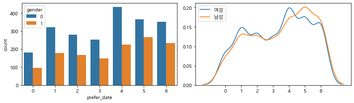

```python
f = tr.groupby('cust_id')['date'].agg([('prefer_date', lambda x: x.value_counts().index[0])]).reset_index()

# 요일을 숫자로 바꿔주기: 월요일: 0 ~ 일요일: 6
f.prefer_date = f.prefer_date.map({'월':0,'화':1,'수':2,'목':3,'금':4,'토':5,'일':6})

f['gender'] = y_train['gender']

figure, ax = plt.subplots(1, 2, figsize=(10, 3))

sns.countplot(data=f, x='prefer_date', hue='gender', ax=ax[0])
sns.kdeplot(f.query('gender==0').prefer_date, label = '여성', ax=ax[1])
sns.kdeplot(f.query('gender==1').prefer_date, label = '남성', ax=ax[1])
plt.xticks([i for i in range(7)])

plt.tight_layout()
plt.show()
```

방문비율

```python
## 요일별 방문비율

for i in trs:

    # 총 방문일수
    total_visits = i.groupby('cust_id')['tran_date'].nunique()

    # 고객별 요일별 방문일수
    temp_datepivot = pd.pivot_table(i, index='cust_id', columns='date', values='tran_date', aggfunc=(lambda x: x.nunique()), fill_value=0)

    # 요일을 숫자로 바꿔주기: 월요일: 0 ~ 일요일: 6
    temp_datepivot = temp_datepivot.rename(columns={'월':0,'화':1,'수':2,'목':3,'금':4,'토':5,'일':6})

    # 칼럼명 변경화
    oldname = temp_datepivot.columns.tolist()
    newname = [str(i)+'_visits' for i in oldname]
    temp_datepivot = temp_datepivot.rename(columns=dict(zip(oldname, newname)))

    # 고객별 요일별 방문비율

    for i in range(len(temp_datepivot.columns)):

            temp_datepivot.iloc[:,i] = temp_datepivot.iloc[:,i] / total_visits

    f = temp_datepivot.reset_index()
    f = f[['cust_id','0_visits','1_visits','2_visits','3_visits','4_visits', '5_visits']]

    features.append(f); f
```

```python
 # 총 방문일수
total_visits = tr.groupby('cust_id')['tran_date'].nunique()

# 고객별 요일별 방문일수
temp_datepivot = pd.pivot_table(tr, index='cust_id', columns='date', values='tran_date', aggfunc=(lambda x: x.nunique()), fill_value=0)

# 요일을 숫자로 바꿔주기: 월요일: 0 ~ 일요일: 6
temp_datepivot = temp_datepivot.rename(columns={'월':0,'화':1,'수':2,'목':3,'금':4,'토':5,'일':6})

# 고객별 요일별 방문비율
for i in range(len(temp_datepivot.columns)):

    temp_datepivot.iloc[:,i] = temp_datepivot.iloc[:,i] / total_visits

f = temp_datepivot.reset_index()
f['gender'] = y_train['gender']
```

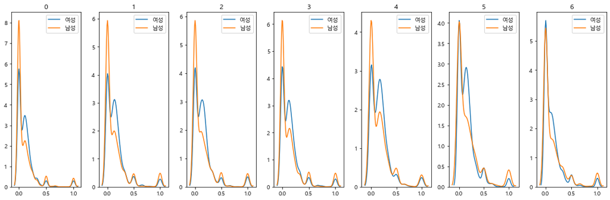

```python
figure, ax = plt.subplots(1, 7, figsize=(15, 5))

for date in range(7):
    sns.kdeplot(f.query('gender==0')[date], label = '여성', ax=ax[date])
    sns.kdeplot(f.query('gender==1')[date], label = '남성', ax=ax[date])
    ax[date].set_title(f'{date}')

plt.tight_layout()
plt.show()
```

구매비율

```python
## 고객별 요일별 구매비율

for i in trs:

    # 고객별 구매금액 총합
    total_amount =  i.groupby('cust_id')['amount'].sum()
    # 고객별 요일별구매금액
    temp_datepivot = pd.pivot_table(i, index='cust_id', columns='date', values='amount', aggfunc=sum, fill_value=0)

    # 요일을 숫자로 바꿔주기: 월요일: 0 ~ 일요일: 6
    temp_datepivot = temp_datepivot.rename(columns={'월':0,'화':1,'수':2,'목':3,'금':4,'토':5,'일':6})

    # 칼럼명 변경화
    oldname = temp_datepivot.columns.tolist()
    newname = [str(i)+'_amount' for i in oldname]
    temp_datepivot = temp_datepivot.rename(columns=dict(zip(oldname, newname)))

    # 고객별 요일별 구매금액비율
    for i in range(len(temp_datepivot.columns)):

        temp_datepivot.iloc[:,i] = temp_datepivot.iloc[:,i] / total_amount

    f = temp_datepivot.reset_index()
    f = f.replace([float('inf'), -float('inf')], [1, -1]).fillna(0)
    features.append(f); f
```

```python
# 고객별 구매금액 총합
total_amount =  tr.groupby('cust_id')['amount'].sum()
# 고객별 요일별구매금액
temp_datepivot = pd.pivot_table(tr, index='cust_id', columns='date', values='amount', aggfunc=sum, fill_value=0)

# 요일을 숫자로 바꿔주기: 월요일: 0 ~ 일요일: 6
temp_datepivot = temp_datepivot.rename(columns={'월':0,'화':1,'수':2,'목':3,'금':4,'토':5,'일':6})

# 고객별 요일별 구매금액비율
for i in range(len(temp_datepivot.columns)):

    temp_datepivot.iloc[:,i] = temp_datepivot.iloc[:,i] / total_amount

f = temp_datepivot.reset_index()
f = f.replace([float('inf'), -float('inf')], [1, -1]).fillna(0)
f['gender'] = y_train['gender']
```

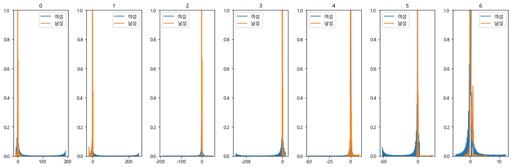

```python
figure, ax = plt.subplots(1, 7, figsize=(15, 5))

for date in range(7):
    sns.kdeplot(f.query('gender==0')[date], label = '여성', ax=ax[date])
    sns.kdeplot(f.query('gender==1')[date], label = '남성', ax=ax[date])
    ax[date].set_title(f'{date}')
    ax[date].set_ylim(0,1)

plt.tight_layout()
plt.show()
```

구매건수

```python
## 고객별 요일별 구매건수

for i in trs:

    temp_datepivot = pd.pivot_table(i, index='cust_id', columns='date', values='amount', aggfunc=np.size, fill_value=0)

    # 요일을 숫자로 바꿔주기: 월요일: 0 ~ 일요일: 6
    temp_datepivot = temp_datepivot.rename(columns={'월':0,'화':1,'수':2,'목':3,'금':4,'토':5,'일':6})

    ## 칼럼명 변경화
    oldname = temp_datepivot.columns.tolist()
    newname = [str(i)+'_buy' for i in oldname]
    temp_datepivot = temp_datepivot.rename(columns=dict(zip(oldname, newname)))

    f = temp_datepivot.reset_index()

    features.append(f); f
```

```python
temp_datepivot = pd.pivot_table(tr, index='cust_id', columns='date', values='amount', aggfunc=np.size, fill_value=0)

# 요일을 숫자로 바꿔주기: 월요일: 0 ~ 일요일: 6
temp_datepivot = temp_datepivot.rename(columns={'월':0,'화':1,'수':2,'목':3,'금':4,'토':5,'일':6})

f = temp_datepivot.reset_index()

f['gender'] = y_train['gender']
```

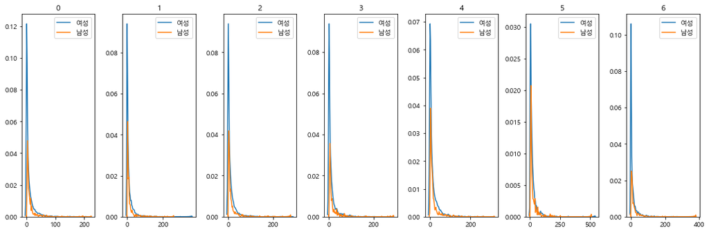

```python
figure, ax = plt.subplots(1, 7, figsize=(15, 5))

for date in range(7):
    sns.kdeplot(f.query('gender==0')[date], label = '여성', ax=ax[date])
    sns.kdeplot(f.query('gender==1')[date], label = '남성', ax=ax[date])
    ax[date].set_title(f'{date}')
plt.tight_layout()
plt.show()
```

주말방문비율

```python
## 주말방문비율

for i in trs:

    f = i.groupby('cust_id')['tran_date'].agg([
        ('weekend_visit_ratio', lambda x: np.mean(pd.to_datetime(x).dt.dayofweek>4))
    ]).reset_index()
    features.append(f); f
```

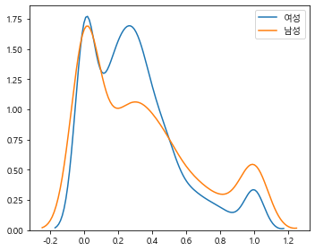

```python
f = tr.groupby('cust_id')['tran_date'].agg([('weekend_visit_ratio', lambda x: np.mean(pd.to_datetime(x).dt.dayofweek>4))]).reset_index()

f['gender'] = y_train['gender']

plt.figure(figsize= (5,4))
sns.kdeplot(f.query('gender==0').weekend_visit_ratio, label = '여성')
sns.kdeplot(f.query('gender==1').weekend_visit_ratio, label = '남성')

plt.tight_layout()
plt.show()
```

고객별 주말구매건수

```python
## 주말 구매건수

for i in trs:

    temp_datepivot = pd.pivot_table(i, index='cust_id', columns='date', values='amount', aggfunc=np.size, fill_value=0)

    f = temp_datepivot[['토','일']].sum(axis=1).reset_index().rename(columns={0:'weekend_buy'})


    bins2 =  [i*10 for i in range(63)]
    f['weekend_buy2'] = pd.cut(f.weekend_buy,bins= bins2,labels=[i for i in range(0,len(bins2)-1)])
    f.weekend_buy2 = f.weekend_buy2.fillna(0)
    f = f.drop('weekend_buy', axis=1)
    features.append(f); f
```

```python
temp_datepivot = pd.pivot_table(tr, index='cust_id', columns='date', values='amount', aggfunc=np.size, fill_value=0)

f = temp_datepivot[['토','일']].sum(axis=1).reset_index().rename(columns={0:'weekend_buy'})

f['gender'] = y_train['gender']
```

```python
bins2 =  [i*10 for i in range(63)]
f['weekend_buy2'] = pd.cut(f.weekend_buy,bins= bins2,labels=[i for i in range(0,len(bins2)-1)])
f.weekend_buy2 = f.weekend_buy2.fillna(0)
```

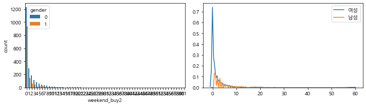

```python
figure, ax = plt.subplots(1, 2, figsize=(10, 3))

sns.countplot(data=f, x='weekend_buy2', hue='gender', ax=ax[0])
sns.kdeplot(f.query('gender==0').weekend_buy2, label = '여성', ax=ax[1])
sns.kdeplot(f.query('gender==1').weekend_buy2, label = '남성', ax=ax[1])

plt.tight_layout()
plt.show()
```

## ────────────────────────────────────────────────────────

### 3. 장소적 관점

만든 피쳐들

방문 지점의 수

```python
## 고객별 방문 지점의 수

for i in trs:

    f = i.groupby('cust_id')['store_nm'].nunique().reset_index().rename(columns={'store_nm':'stores_count'})

    features.append(f); f
```

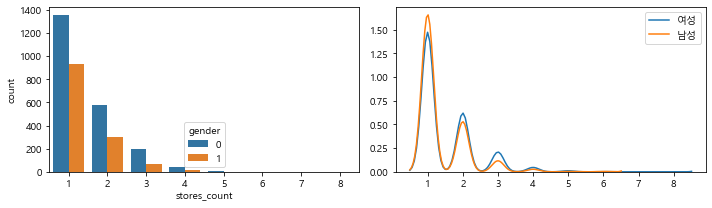

```python
f = tr.groupby('cust_id')['store_nm'].nunique().reset_index().rename(columns={'store_nm':'stores_count'})

f['gender'] = y_train['gender']


figure, ax = plt.subplots(1, 2, figsize=(10, 3))

sns.countplot(data=f, x='stores_count', hue='gender', ax=ax[0])
sns.kdeplot(f.query('gender==0').stores_count, label = '여성', ax=ax[1])
sns.kdeplot(f.query('gender==1').stores_count, label = '남성', ax=ax[1])

plt.tight_layout()
plt.show()
```

많이 방문한 지점들 best-12 순위별 방문비율

```
- top-12가 전체 24개의 점포중 91% 데이터를 차지한다.
```

```python
## 전체의 90프로를 넘게 차지하는 12개의 점포 데이터

for i in trs:

    print(i.store_nm.value_counts()[:12].sum() / i.store_nm.value_counts().sum())
```

```
0.9145704384407165
0.9261790924320424
```

```python
top12store_all = []

for i in trs:

    ## top-12에 해당하는 지점들

    top12store = i.store_nm.value_counts()[:12].index.tolist()

    top12store_all.append(top12store)

top12store_train = top12store_all[0]; print(top12store_train)
top12store_test = top12store_all[1]; print(top12store_test)
print()
intersection_store = list(set(top12store_train).intersection(top12store_test)); print(intersection_store)
print('겹치는 지점 수: ', len(intersection_store))
```

```
['본  점', '분당점', '잠실점', '부산본점', '일산점', '노원점', '광주점', '영등포점', '강남점', '부평점', '청량리점', '대전점']
['본  점', '분당점', '잠실점', '일산점', '강남점', '부산본점', '청량리점', '광주점', '영등포점', '미아점', '노원점', '부평점']

['부산본점', '강남점', '영등포점', '부평점', '청량리점', '노원점', '잠실점', '분당점', '본  점', '광주점', '일산점']
겹치는 지점 수:  11
```

```python
## intersection_store 방문비율

for i in trs:
    ## nan값 방지
    if len(i) == 232004:
        merge_tempdf = pd.DataFrame({'cust_id': np.arange(3500)})
    else:
        merge_tempdf = pd.DataFrame({'cust_id': np.arange(3500,5982)})

    # 고객별 전체방문일수
    total_visits = i.groupby('cust_id')['tran_date'].nunique()
    # 고객별 점포별 방문일수
    temp_storepivot = pd.pivot_table(i.query('store_nm in @intersection_store'), index='cust_id', columns='store_nm', values='tran_date', aggfunc=(lambda x: x.nunique()), fill_value=0)


    # 칼럼명 영문화
    engname = temp_storepivot.columns.tolist()
    newname = [str(i*10)+'_visits' for i in range(len(engname))]
    temp_storepivot = temp_storepivot.rename(columns=dict(zip(engname, newname)))

    # 고객별 점포별 방문비율
    for i in range(len(temp_storepivot.columns)):

        temp_storepivot.iloc[:,i] = temp_storepivot.iloc[:,i] / total_visits

    f = temp_storepivot.reset_index()
    f = pd.merge(merge_tempdf, f, how='outer').fillna(0)


    bins = [0, 0.2, 0.4, 0.6, 0.8, 1.0]
    labels = [0, 0.2, 0.4, 0.6, 0.8]

    for i in range(11):

        f[f'{i}_visits{i}'] = pd.cut(f[f'{i*10}_visits'], bins= bins, labels = labels)
        f = f.drop(f'{i*10}_visits', axis=1)
    f = f.fillna(0)
    features.append(f); f
```

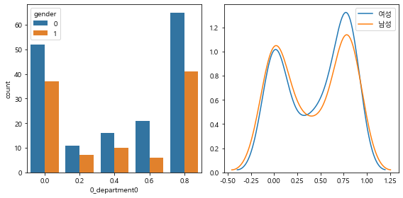

```python
# 고객별 전체방문일수
total_visits = tr.groupby('cust_id')['tran_date'].nunique()
# 고객별 점포별 방문일수
temp_storepivot = pd.pivot_table(tr.query('store_nm in @top12store'), index='cust_id', columns='store_nm', values='tran_date', aggfunc=(lambda x: x.nunique()), fill_value=0)

# 칼럼명 영문화
engname = temp_storepivot.columns.tolist()
newname = [str(i*10)+'_department' for i in range(len(engname))]
temp_storepivot = temp_storepivot.rename(columns=dict(zip(engname, newname)))

# 고객별 점포별 방문비율
for i in range(len(temp_storepivot.columns)):

     temp_storepivot.iloc[:,i] = temp_storepivot.iloc[:,i] / total_visits

f = temp_storepivot.reset_index()
f['gender'] = y_train['gender']


bins = [0, 0.2, 0.4, 0.6, 0.8, 1.0]
labels = [0, 0.2, 0.4, 0.6, 0.8]

for i in range(12):

    f[f'{i}_department{i}'] = pd.cut(f[f'{i*10}_department'], bins= bins, labels = labels)


figure, ax = plt.subplots(1, 2, figsize = (8, 4))
sns.countplot(data=f, x=f['0_department0'], hue='gender', ax=ax[0])

sns.kdeplot(f.query('gender==0')['0_department0'], label='여성', ax=ax[1])
sns.kdeplot(f.query('gender==1')['0_department0'], label='남성', ax=ax[1])

plt.tight_layout()
plt.show()
```

많이 방문한 지점들 best-12 순위별 구매금액비율

```python
## intersection_store 구매금액비율

for i in trs:

    ## nan값 방지
    if len(i) == 232004:
        merge_tempdf = pd.DataFrame({'cust_id': np.arange(3500)})
    else:
        merge_tempdf = pd.DataFrame({'cust_id': np.arange(3500,5982)})

    # 고객별 구매금액 총합
    total_amount =  i.groupby('cust_id')['amount'].sum()
    # 고객별 점포별 구매금액
    temp_storepivot = pd.pivot_table(i.query('store_nm in @intersection_store'), index='cust_id', columns='store_nm', values='amount', aggfunc=sum, fill_value=0)

    # 칼럼명 영문화
    engname = temp_storepivot.columns.tolist()
    newname = [str(i*10)+'_amount_ratio' for i in range(len(engname))]
    temp_storepivot = temp_storepivot.rename(columns=dict(zip(engname, newname)))

    # 고객별 점포별 구매금액비율
    for i in range(len(temp_storepivot.columns)):

        temp_storepivot.iloc[:,i] = temp_storepivot.iloc[:,i] / total_amount

    f = temp_storepivot.reset_index()
    f = pd.merge(merge_tempdf, f, how='outer').fillna(0)


    bins = [0, 0.1, 0.2, 0.3, 0.4, 0.5, 0.6, 0.7, 0.8, 0.9, 1.0]
    labels = [0, 0.1, 0.2, 0.3, 0.4, 0.5, 0.6, 0.7, 0.8, 0.9]

    for i in range(11):

        f[f'{i}_amount_ratio{i}'] = pd.cut(f[f'{i*10}_amount_ratio'], bins= bins, labels = labels)
        f = f.drop(f'{i*10}_amount_ratio', axis=1)
    f = f.fillna(0)
    features.append(f); f
```

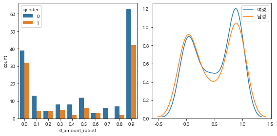

```python
# 고객별 구매금액 총합
total_amount =  tr.groupby('cust_id')['amount'].sum()
# 고객별 점포별 구매금액
temp_storepivot = pd.pivot_table(tr.query('store_nm in @top12store'), index='cust_id', columns='store_nm', values='amount', aggfunc=sum, fill_value=0)

# 칼럼명 영문화
engname = temp_storepivot.columns.tolist()
newname = [str(i*10)+'_amount_ratio' for i in range(len(engname))]
temp_storepivot = temp_storepivot.rename(columns=dict(zip(engname, newname)))

# 고객별 점포별 구매금액비율
for i in range(len(temp_storepivot.columns)):

    temp_storepivot.iloc[:,i] = temp_storepivot.iloc[:,i] / total_amount

f = temp_storepivot.reset_index()
f['gender'] = y_train['gender']

bins = [0, 0.1, 0.2, 0.3, 0.4, 0.5, 0.6, 0.7, 0.8, 0.9, 1.0]
labels = [0, 0.1, 0.2, 0.3, 0.4, 0.5, 0.6, 0.7, 0.8, 0.9]

for i in range(12):

    f[f'{i}_amount_ratio{i}'] = pd.cut(f[f'{i*10}_amount_ratio'], bins= bins, labels = labels)

figure, ax = plt.subplots(1, 2, figsize = (8, 4))
sns.countplot(data=f, x=f['0_amount_ratio0'], hue='gender', ax=ax[0])

sns.kdeplot(f.query('gender==0')['0_amount_ratio0'], label='여성', ax=ax[1])
sns.kdeplot(f.query('gender==1')['0_amount_ratio0'], label='남성', ax=ax[1])

plt.tight_layout()
plt.show()
```

많이 방문한 지점들 best-12 순위별 구매건수

```
- 구매건수를 bins1 = [i*5 for i in range(195)]
```

```python
## 고객별 top-12 점포 구매건수

for i in trs:

    ## nan값 방지
    if len(i) == 232004:
        merge_tempdf = pd.DataFrame({'cust_id': np.arange(3500)})
    else:
        merge_tempdf = pd.DataFrame({'cust_id': np.arange(3500,5982)})

    # 고객별 점포별 구매건수
    temp_storepivot = pd.pivot_table(i.query('store_nm in @intersection_store'), index='cust_id', columns='store_nm', values='amount', aggfunc=np.size, fill_value=0)

    # 칼럼명 영문화
    engname = temp_storepivot.columns.tolist()
    newname = [str(i*10)+'_num_of_pur' for i in range(len(engname))]
    temp_storepivot = temp_storepivot.rename(columns=dict(zip(engname, newname)))

    f = temp_storepivot.reset_index()
    f = pd.merge(merge_tempdf, f, how='outer').fillna(0)


    for i in range(11):

        bins = [i*5 for i in range(round(f[f'{i*10}_num_of_pur'].max()/5) + 2)]
        labels = [i for i in range(len(bins)-1)]

        f[f'{i}_num_of_pur{i}'] = pd.cut(f[f'{i*10}_num_of_pur'], bins= bins, labels = labels)
        f = f.drop(f'{i*10}_num_of_pur', axis=1)

    f = f.fillna(0)
    features.append(f); f
```

```python
f
```

|  | cust_id | 0_num_of_pur0 | 1_num_of_pur1 | 2_num_of_pur2 | 3_num_of_pur3 | 4_num_of_pur4 | 5_num_of_pur5 | 6_num_of_pur6 | 7_num_of_pur7 | 8_num_of_pur8 | 9_num_of_pur9 | 10_num_of_pur10 |
| --- | --- | --- | --- | --- | --- | --- | --- | --- | --- | --- | --- | --- |
| 0 | 3500 | 0 | 0 | 0 | 0 | 3 | 0 | 0 | 0 | 0 | 0 | 0 |
| 1 | 3501 | 0 | 0 | 0 | 0 | 0 | 0 | 0 | 0 | 0 | 43 | 0 |
| 2 | 3502 | 0 | 0 | 0 | 295 | 0 | 0 | 0 | 0 | 0 | 0 | 0 |
| 3 | 3503 | 0 | 0 | 0 | 0 | 1 | 0 | 0 | 0 | 0 | 0 | 0 |
| 4 | 3504 | 0 | 0 | 0 | 0 | 0 | 0 | 0 | 0 | 0 | 0 | 1 |
| ... | ... | ... | ... | ... | ... | ... | ... | ... | ... | ... | ... | ... |
| 2477 | 5977 | 0 | 0 | 0 | 0 | 1 | 0 | 0 | 0 | 0 | 0 | 0 |
| 2478 | 5978 | 0 | 0 | 0 | 0 | 0 | 0 | 0 | 0 | 0 | 0 | 0 |
| 2479 | 5979 | 0 | 0 | 0 | 14 | 0 | 0 | 0 | 0 | 0 | 0 | 0 |
| 2480 | 5980 | 0 | 0 | 0 | 3 | 0 | 0 | 0 | 0 | 0 | 0 | 0 |
| 2481 | 5981 | 0 | 0 | 0 | 0 | 0 | 0 | 0 | 1 | 0 | 0 | 0 |

2482 rows × 12 columns

## ────────────────────────────────────────────────────────

### 4. 제품적 관점

주구매상품1

-> 주구매 상품: 가장 많이 구매한 상품(goods_id)

```
 - 총 3471개 물품 중 3500명이 가장 많이 사는 물품들은 850개정도로 겹치는 물품들이 있다
```

```python
## goods_id 구매한 물품 중 가장 많이 구매한 물품

for i in trs:

    f = i.groupby('cust_id')['goods_id'].agg([
        ('main_product_goods', lambda x: x.value_counts().index[0])
    ]).reset_index()
    features.append(f); f
```

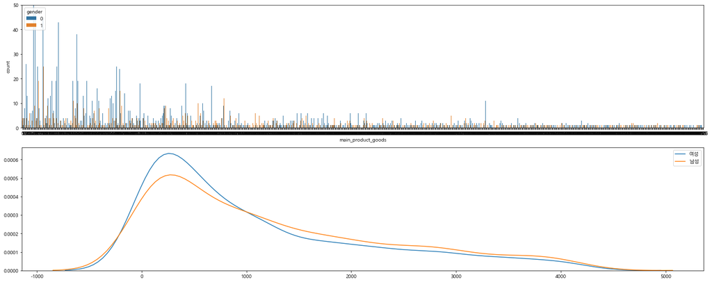

```python
f = tr.groupby('cust_id')['goods_id'].agg([
    ('main_product_goods', lambda x: x.value_counts().index[0])
]).reset_index()

str_name = f.main_product_goods.unique().tolist()
num_name = [i*5 for i in range(len(str_name))]
f.main_product_goods = f.main_product_goods.map(dict(zip(str_name, num_name)))

f['gender'] = y_train['gender']

figure, ax = plt.subplots(2, 1, figsize=(20, 8))

sns.countplot(data=f, x='main_product_goods', hue='gender', ax=ax[0])
ax[0].set_ylim(0,50)
sns.kdeplot(f.query('gender==0').main_product_goods, label = '여성', ax=ax[1])
sns.kdeplot(f.query('gender==1').main_product_goods, label = '남성', ax=ax[1])

plt.tight_layout()
plt.show()
```

주구매상품2

```
- 총 324개 중 203개로 겹치는 gds_grp_nm이 존재한다
- 겹치면서 많이 구매한 물품들에 있어서 남/녀를 구분할 수 있는 제품들이 있기 때문에 피쳐로 채택
```

```python
for i in trs:

    f = i.groupby('cust_id')['gds_grp_nm'].agg([
        ('main_product_nm', lambda x: x.value_counts().index[0])
    ]).reset_index()

    # 주구매상품중분류 문자를 숫자로 바꿔주기
    str_name = f.main_product_nm.unique().tolist()
    num_name = [i for i in range(len(str_name))]
    f.main_product_nm = f.main_product_nm.map(dict(zip(str_name, num_name)))

    features.append(f); f
```

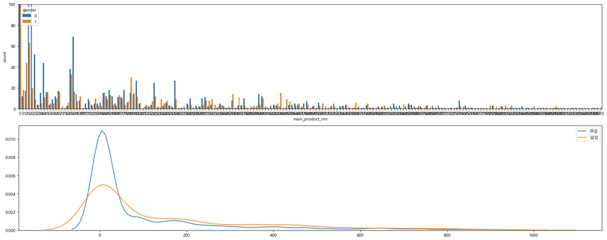

```python
f = tr.groupby('cust_id')['gds_grp_nm'].agg([('main_product_nm', lambda x: x.value_counts().index[0])]).reset_index()

str_name = f.main_product_nm.unique().tolist()
num_name = [i*5 for i in range(len(str_name))]
f.main_product_nm = f.main_product_nm.map(dict(zip(str_name, num_name)))

f['gender'] = y_train['gender']

figure, ax = plt.subplots(2, 1, figsize=(20, 8))

sns.countplot(data=f, x='main_product_nm', hue='gender', ax=ax[0])
ax[0].set_ylim(0,100)
sns.kdeplot(f.query('gender==0').main_product_nm, label = '여성', ax=ax[1])
sns.kdeplot(f.query('gender==1').main_product_nm, label = '남성', ax=ax[1])

plt.tight_layout()
plt.show()
```

주구매상품3

```
- 총 49개 중 42개로 겹치는 gds_grp_mclas_nm이 존재한다
- 겹치면서 많이 구매한 물품들에 있어서 남/녀를 구분할 수 있는 제품들이 있기 때문에 피쳐로 채택
```

가장 많이 구매한 상품(gds_grp_mclas_nm)

```python
for i in trs:

    f = i.groupby('cust_id')['gds_grp_mclas_nm'].agg([
        ('main_product_mclas', lambda x: x.value_counts().index[0])
    ]).reset_index()

    # 주구매상품대분류 문자를 숫자로 바꿔주기
    str_name = f.main_product_mclas.unique().tolist()
    num_name = [i for i in range(len(str_name))]
    f.main_product_mclas = f.main_product_mclas.map(dict(zip(str_name, num_name)))

    features.append(f); f
```

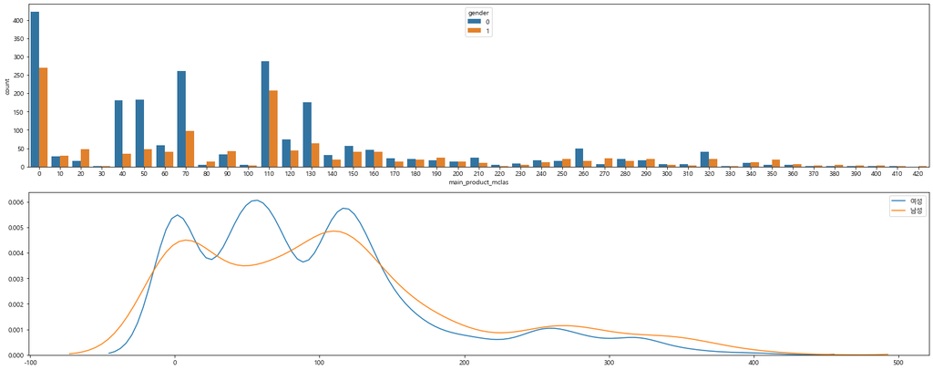

```python
f = tr.groupby('cust_id')['gds_grp_mclas_nm'].agg([('main_product_mclas', lambda x: x.value_counts().index[0])]).reset_index()

# 상품대분류명군 문자를 숫자로 바꿔주기
str_name = f.main_product_mclas.unique().tolist()
num_name = [i*10 for i in range(len(str_name))]
f.main_product_mclas = f.main_product_mclas.map(dict(zip(str_name, num_name)))

f['gender'] = y_train['gender']

figure, ax = plt.subplots(2, 1, figsize=(20, 8))

sns.countplot(data=f, x='main_product_mclas', hue='gender', ax=ax[0])
sns.kdeplot(f.query('gender==0').main_product_mclas, label = '여성', ax=ax[1])
sns.kdeplot(f.query('gender==1').main_product_mclas, label = '남성', ax=ax[1])

plt.tight_layout()
plt.show()
```

상품별 구매순서

```python
# 가장 먼저 방문하는 상품대분류명군

temp_lst = []
for i in range(3500):
    temp_lst.append(tr.query(f'cust_id == {i}').drop_duplicates('tran_date')['gds_grp_mclas_nm'].value_counts().index[0])

f = pd.DataFrame({'cust_id': np.arange(3500)})
f['first_visit_place'] = temp_lst

# 상품대분류명군 문자를 숫자로 바꿔주기
str_name = f.first_visit_place.unique().tolist()
num_name = [i*5 for i in range(len(str_name))]
f.first_visit_place = f.first_visit_place.map(dict(zip(str_name, num_name)))

features.append(f); f
```

|  | cust_id | first_visit_place |
| --- | --- | --- |
| 0 | 0 | 0 |
| 1 | 1 | 5 |
| 2 | 2 | 10 |
| 3 | 3 | 15 |
| 4 | 4 | 20 |
| ... | ... | ... |
| 3495 | 3495 | 120 |
| 3496 | 3496 | 25 |
| 3497 | 3497 | 100 |
| 3498 | 3498 | 0 |
| 3499 | 3499 | 0 |

3500 rows × 2 columns

```python
# 가장 먼저 방문하는 상품대분류명군

temp_lst = []
for i in range(3500,5982):
    temp_lst.append(tr2.query(f'cust_id == {i}').drop_duplicates('tran_date')['gds_grp_mclas_nm'].value_counts().index[0])

f = pd.DataFrame({'cust_id': np.arange(3500,5982)})
f['first_visit_place'] = temp_lst

  # 상품대분류명군 문자를 숫자로 바꿔주기
str_name = f.first_visit_place.unique().tolist()
num_name = [i*5 for i in range(len(str_name))]
f.first_visit_place = f.first_visit_place.map(dict(zip(str_name, num_name)))

features.append(f); f
```

|  | cust_id | first_visit_place |
| --- | --- | --- |
| 0 | 3500 | 0 |
| 1 | 3501 | 5 |
| 2 | 3502 | 10 |
| 3 | 3503 | 15 |
| 4 | 3504 | 20 |
| ... | ... | ... |
| 2477 | 5977 | 0 |
| 2478 | 5978 | 40 |
| 2479 | 5979 | 195 |
| 2480 | 5980 | 120 |
| 2481 | 5981 | 105 |

2482 rows × 2 columns

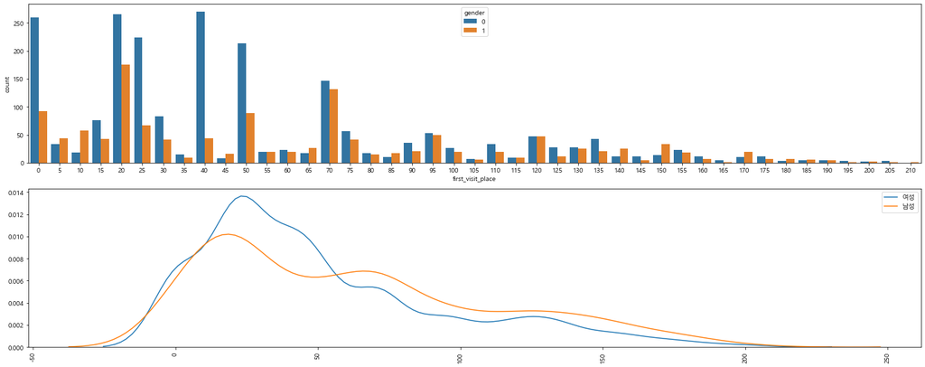

```python
temp_lst = []
for i in range(3500):
    temp_lst.append(tr.query(f'cust_id == {i}').drop_duplicates('tran_date')['gds_grp_mclas_nm'].value_counts().index[0])

f = pd.DataFrame({'cust_id': np.arange(3500)})
f['first_visit_place'] = temp_lst

# 상품대분류명군 문자를 숫자로 바꿔주기
str_name = f.first_visit_place.unique().tolist()
num_name = [i*5 for i in range(len(str_name))]
f.first_visit_place = f.first_visit_place.map(dict(zip(str_name, num_name)))

f['gender'] = y_train['gender']

figure, ax = plt.subplots(2, 1, figsize=(20, 8))

sns.countplot(data=f, x='first_visit_place', hue='gender', ax=ax[0])
plt.xticks(rotation=90)
sns.kdeplot(f.query('gender==0').first_visit_place, label = '여성', ax=ax[1])
sns.kdeplot(f.query('gender==1').first_visit_place, label = '남성', ax=ax[1])

plt.tight_layout()
plt.show()
```

구매상품종류1(goods_id), 구매상품종류2(gds_grp_nm), 구매상품종류3(gds_grp_mclas_nm)

```python
for i in trs:

    f = i.groupby('cust_id').agg({
        'goods_id': [('num_pur_type1', lambda x: x.nunique())],
        'gds_grp_nm': [('num_pur_type2', lambda x: x.nunique())],
        'gds_grp_mclas_nm': [('num_pur_type3', lambda x: x.nunique())]
    })

    f.columns = f.columns.droplevel()  # 동일한 코드: f.columns = [j for _, j in f.columns]
    f=f.reset_index()
    features.append(f); f
```

```python
f = tr.groupby('cust_id').agg({
    'goods_id': [('num_pur_type1', lambda x: x.nunique())],
    'gds_grp_nm': [('num_pur_type2', lambda x: x.nunique())],
    'gds_grp_mclas_nm': [('num_pur_type3', lambda x: x.nunique())]
})

f.columns = f.columns.droplevel()  # 동일한 코드: f.columns = [j for _, j in f.columns]
f=f.reset_index()

f['gender'] = y_train['gender']
```

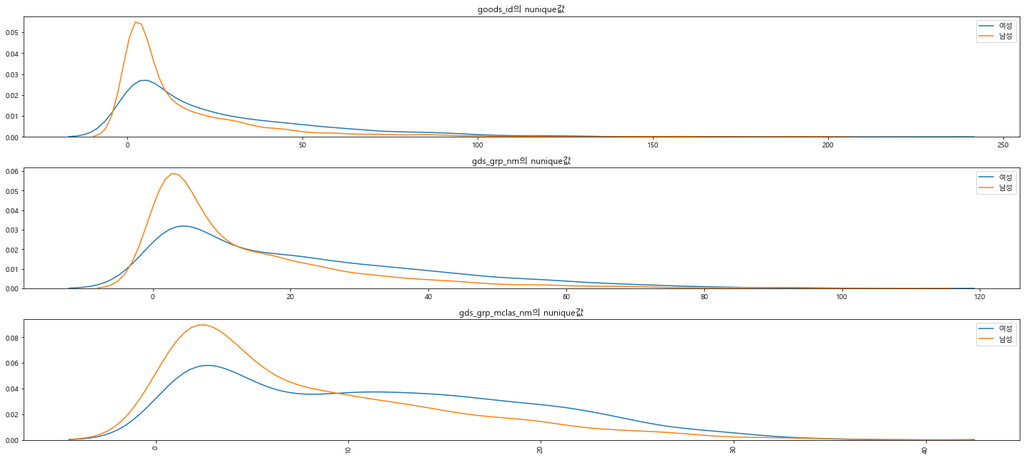

```python
figure , ax = plt.subplots(3, 1, figsize=(20,9))

for i in range(3):
    sns.kdeplot(f.query('gender==0')[f'num_pur_type{i+1}'], label='여성', ax=ax[i])
    sns.kdeplot(f.query('gender==1')[f'num_pur_type{i+1}'], label='남성', ax=ax[i])
ax[0].set_title('goods_id의 nunique값')
ax[1].set_title('gds_grp_nm의 nunique값')
ax[2].set_title('gds_grp_mclas_nm의 nunique값')
plt.xticks(rotation=90)
plt.tight_layout()
plt.show()
```

### 상품 분류별 top-x 구매금액비율 , 구매건수

- 상품분류별 중 90퍼센트 이상을 차지하는 상품들의 구매금액비율과 구매건수를 구한다
- train과 test에서 겹치는 부분을 뽑아내기 때문에 칼럼 수가 줄어든다.

  ```
   - goods_id(상품소분류별) top550 구매금액비율, 구매건수
   - gds_grp_nm(상품중분류별) top75 구매금액비율, 구매건수
   - gds_grp_mclas_nm(상품대분류별) top25 구매금액비율, 구매건수
  ```

많이 구매한 상품소분류별 best-x 구매금액비율, 구매건수(3471 중 x)

```python
top550goods_all = []

for i in trs:

    ## 전체 구매금액
    total = i.amount.sum()

    ## 전체 구매금액 중 goods_id top550이 전체의 90퍼센트 정도를 차지한다.

    top550 = i.groupby('goods_id')['amount'].sum().reset_index().sort_values('amount', ascending=False)[:550]

    top550sum = top550['amount'].sum()

    top550goods = top550['goods_id'].tolist()

    top550goods_all.append(top550goods)

    print(top550sum / total)
```

```
0.9034186144204891
0.910431874144973
```

```python
## 교차항목 뽑아내기

train_top550 = top550goods_all[0]; print(len(train_top550))
test_top550 = top550goods_all[1]; print(len(test_top550))
print()
intersection550 = list(set(train_top550).intersection(test_top550)); print('겹치는 항목:',len(intersection550))
```

```
550
550

겹치는 항목: 483
```

```python
for i in trs:
    ## nan값 방지
    if len(i) == 232004:
        merge_tempdf = pd.DataFrame({'cust_id': np.arange(3500)})
    else:
        merge_tempdf = pd.DataFrame({'cust_id': np.arange(3500,5982)})

    # 고객별 전체 구매금액
    totalsum = i.groupby('cust_id')['amount'].sum()

    temp_goodsdf = i.query('goods_id in @intersection550')

## intersection550 구매금액비율
    temp_goodspivot = pd.pivot_table(temp_goodsdf, index='cust_id', columns='goods_id', values='amount', aggfunc=sum, fill_value=0)

    for i in range(len(temp_goodspivot.columns)):
        temp_goodspivot.iloc[:,i] = temp_goodspivot.iloc[:,i] / totalsum

    f = temp_goodspivot.reset_index()
    f = pd.merge(merge_tempdf, f, how='outer').fillna(0)

## intersection550 구매금액건수

    temp_goodspivot = pd.pivot_table(temp_goodsdf, index='cust_id', columns='goods_id', values='amount', aggfunc=np.size, fill_value=0)

    # 변수명이 겹치는 것을 막기 위해서 변수명을 다르게 바꿔주는 과정
    oldname = temp_goodspivot.columns.tolist()
    newname = [(str(i)+'_buy') for i in oldname]
    temp_goodspivot = temp_goodspivot.rename(columns = dict(zip(oldname, newname)))

    f2 = temp_goodspivot.reset_index() # 3258행
    f = pd.merge(f, f2, how='outer').fillna(0)

    features.append(f); f
```

많이 구매한 상품중분류별 best-y 구매금액비율, 구매건수비율(324 중 y)

```python
top75goods_all = []

for i in trs:

    ## 전체 구매금액
    total = i.amount.sum()

    ## 전체 구매금액 중 gds_grp_nm top75이 전체의 90퍼센트 정도를 차지한다.

    top75 = i.groupby('gds_grp_nm')['amount'].sum().reset_index().sort_values('amount', ascending=False)[:75]

    top75sum = top75['amount'].sum()

    top75goods = top75['gds_grp_nm'].tolist()

    top75goods_all.append(top75goods)

    print(top75sum / total)
```

```
0.9099637919037719
0.9127326259610689
```

```python
## 교차항목 뽑아내기

train_top75 = top75goods_all[0]; print(len(train_top75))
test_top75 = top75goods_all[1]; print(len(test_top75))
print()
intersection75 = list(set(train_top75).intersection(test_top75)); print('겹치는 항목:',len(intersection75))
```

```
75
75

겹치는 항목: 72
```

```python
for i in trs:
    ## nan값 방지
    if len(i) == 232004:
        merge_tempdf = pd.DataFrame({'cust_id': np.arange(3500)})
    else:
        merge_tempdf = pd.DataFrame({'cust_id': np.arange(3500,5982)})

    # 고객별 전체 구매금액
    totalsum = i.groupby('cust_id')['amount'].sum()

## intersection75 구매금액비율
    temp_goodsdf = i.query('gds_grp_nm in @intersection75')

    temp_goodspivot = pd.pivot_table(temp_goodsdf, index='cust_id', columns='gds_grp_nm', values='amount', aggfunc=sum, fill_value=0)

    # 변수명 영문화
    kor_name = temp_goodspivot.columns.tolist()
    newname = [str(i*3)+'grp_nm' for i in range(len(kor_name))]
    temp_goodspivot = temp_goodspivot.rename(columns=dict(zip(kor_name, newname)))

    for i in range(len(temp_goodspivot.columns)):
        temp_goodspivot.iloc[:,i] = temp_goodspivot.iloc[:,i] / totalsum

    f = temp_goodspivot.reset_index()
    f = pd.merge(merge_tempdf, f, how='outer').fillna(0)


## intersection75 구매금액건수

    temp_goodspivot = pd.pivot_table(temp_goodsdf, index='cust_id', columns='gds_grp_nm', values='amount', aggfunc=np.size, fill_value=0)

    # 변수명 영문화
    kor_name = temp_goodspivot.columns.tolist()
    newname = [str(i*3)+'grp_nm_buy' for i in range(len(kor_name))]
    temp_goodspivot = temp_goodspivot.rename(columns=dict(zip(kor_name, newname)))

    f2 = temp_goodspivot.reset_index()
    f = pd.merge(f, f2, how='outer').fillna(0)

    features.append(f); f
```

많이 구매한 상품대분류별 best-z 구매금액비율, 구매건수비율(49 중 z)

```python
top25goods_all = []

for i in trs:

    ## 전체 구매금액
    total = i.amount.sum()

    ## 전체 구매금액 중 gds_grp_mclas_nm top25이 전체의 90퍼센트 정도를 차지한다.
    top25 = i.groupby('gds_grp_mclas_nm')['amount'].sum().reset_index().sort_values('amount', ascending=False)[:25]

    top25sum = top25['amount'].sum()

    top25goods = top25['gds_grp_mclas_nm'].tolist()

    top25goods_all.append(top25goods)

    print(top25sum / total)
```

```
0.9232754143371885
0.9259379619745215
```

```python
## 교차항목 뽑아내기

train_top25 = top25goods_all[0]; print(len(train_top25))
test_top25 = top25goods_all[1]; print(len(test_top25))
print()
intersection25 = list(set(train_top25).intersection(test_top25)); print('겹치는 항목:',len(intersection25))
```

```
25
25

겹치는 항목: 24
```

```python
for i in trs:
    ## nan값 방지
    if len(i) == 232004:
        merge_tempdf = pd.DataFrame({'cust_id': np.arange(3500)})
    else:
        merge_tempdf = pd.DataFrame({'cust_id': np.arange(3500,5982)})

    # 고객별 전체 구매금액
    totalsum = i.groupby('cust_id')['amount'].sum()

## intersection25 구매금액비율
    temp_goodsdf = i.query('gds_grp_mclas_nm in @intersection25')

    temp_goodspivot = pd.pivot_table(temp_goodsdf, index='cust_id', columns='gds_grp_mclas_nm', values='amount', aggfunc=sum, fill_value=0)

    # 변수명 영문화
    kor_name = temp_goodspivot.columns.tolist()
    newname = [str(i*3)+'mclas_nm' for i in range(len(kor_name))]
    temp_goodspivot = temp_goodspivot.rename(columns=dict(zip(kor_name, newname)))

    for i in range(len(temp_goodspivot.columns)):
        temp_goodspivot.iloc[:,i] = temp_goodspivot.iloc[:,i] / totalsum

    f = temp_goodspivot.reset_index()
    f = pd.merge(merge_tempdf, f, how='outer').fillna(0)

## intersection25 구매건수

    temp_goodspivot = pd.pivot_table(temp_goodsdf, index='cust_id', columns='gds_grp_mclas_nm', values='amount', aggfunc=np.size, fill_value=0)

    # 변수명 영문화
    kor_name = temp_goodspivot.columns.tolist()
    newname = [str(i*3)+'mclas_nm_buy' for i in range(len(kor_name))]
    temp_goodspivot = temp_goodspivot.rename(columns=dict(zip(kor_name, newname)))

    f2 = temp_goodspivot.reset_index()
    f = pd.merge(f, f2, how='outer').fillna(0)

    features.append(f); f
```

## ────────────────────────────────────────────────────────

### 5. 기타적 관점

none

## 남녀가 어떤 상품들을 구매하는지, 상품으로써 남녀를 구분하는 피쳐를 생성하고자 한다

### process

#### ch.1 -> 남성경향제품 구매여부(조건: 남성이 여성보다 구매수가 많으면서 남성이 적어도 3번이상 구매한 제품)

```
- 1. 상품대분류명 살펴보기(gds_grp_mclas_nm)
- 2. 상품중분류명 살펴보기(gds_grp_nm)
- 3. 상품소분류명 살펴보기(goods_id)
- 4. goods_id에서 남성이 여성보다 더 많이 구매한 물품목록 뽑아내기
- 5. 뽑아낸 물품목록으로 피쳐 생성하기
```

#### ch.2 -> 여성경향제품 구매여부(조건: 여성만 구매 & 여성이 최소 해당 물품 3회이상 구매 & 여성 최소 3명이 해당 물품구매)

```
          -> (or 이 아니라 and로 모두 해당 조건을 모두 만족하는 물품만 뽑았다)
- 1. 남성만 혹은 여성만 구매하는 제품을 조사
- 2. 여성만 구매한 제품목록 뽑아내기
- 3. 뽑아낸 물품목록으로 피쳐 생성하기
```

```
-> 뽑아낸 피쳐 저장: train_eda_gender_tendency, test_eda_gender_tendency
```